# Diffusion statistics on a phylogenetic tree

Marco Pagni

2023-09-07

## R initialisation

Initialize the R environment and define two directory paths - you may need to update those for your system!

```r
library( dplyr )
library( tidyr )
library( readr )
library( igraph )
library( diffuStats )
library( visNetwork )
library( kableExtra )

# FIXME: update the following two variables to match your system
script_path = '~/github/summer-school-multiomics-data-analysis-and-integration/topic_3/2-Diffusion-Statistics/'
data_path   = '~/github/summer-school-multiomics-data-analysis-and-integration/topic_2/datasets/TaraOceans/'

setwd( script_path )
```

## Load (and fix) the TARA oceans datasets

`TARAoceans_metadata` contains three columns with string codes for sample, ocean and depth.

```r
TARAoceans_metadata <-
    read_csv(
        paste0( data_path, 'TARAoceans_metadata.csv' ),
        show_col_types = F
    ) %>%
    rename( sample = 1 )

TARAoceans_metadata %>%
    slice_head( n = 5 ) %>%
    kable() %>%
    kable_minimal( full_width = F )
```

| sample | ocean | depth |
| --- | --- | --- |
| TARA_109_SRF | SPO | SRF |
| TARA_149_MES | NAO | MES |
| TARA_110_MES | SPO | MES |
| TARA_102_MES | SPO | MES |
| TARA_142_SRF | NAO | SRF |

`TARAoceans_specfreq` contains a table with the raw read counts for the different “species” in the different samples. Nota Bene: (i) we use the wording “species” here for what should be called Operational Taxonomic Unit (OTU) (ii) the source file name contains the wording “Phylo” which would make more sense for the next file.

```r
TARAoceans_specfreq <-
    read_csv(
        paste0( data_path, 'TARAoceans_proPhylo.csv' ),
        show_col_types = F
    ) %>%
    rename( sample = 1 )

TARAoceans_specfreq %>%
    slice_head( n = 5 ) %>%
    select( 1:6 ) %>%
    kable() %>%
    kable_minimal( full_width = F )
```

| sample | EU638706.1.1353 | JN537192.1.1500 | CAFJ01000195.23.1515 | AJ567555.1.1514 | JQ452773.1.1411 |
| --- | --- | --- | --- | --- | --- |
| TARA_109_SRF | 0 | 0 | 0 | 0 | 0 |
| TARA_149_MES | 0 | 0 | 0 | 0 | 0 |
| TARA_110_MES | 0 | 4 | 0 | 0 | 0 |
| TARA_102_MES | 0 | 1 | 0 | 0 | 0 |
| TARA_142_SRF | 0 | 3 | 0 | 0 | 0 |

`TARAoceans_lineage` contains a table with the lineage of every “species”. Some lineages were corrected with respect to `NA`, `uncultured`, `Family Incertae Sedis`, … taxa. Indeed, these correspond to different entities despite a shared designation and must be distinguished by introducing placeholder taxa. This also permit to preserve branch lengths in the final phylogenetic tree. It might be difficult to detect such shared designation in large dataset. Graphical visualisation might help. The `cleanup_uppertaxon` is totally adhoc, but fix the problem.

```r
cleanup_uppertaxon <- function( species, uppertaxon, rank ){
    return(
        ifelse(
            is.na( uppertaxon ) | ( uppertaxon  %in% c(
                'uncultured',
                'Family Incertae Sedis',
                'Family XII Incertae Sedis',
                'FamilyI',
                'Incertae Sedis',
                'Order Incertae Sedis',
                'Marinicella',
                'Prochlorococcus'
            )),
            paste0( rank, '_of_', species ),
            paste0( uppertaxon, '_', rank )
        )
    );
}

TARAoceans_lineage <-
    read_csv(
        paste0( data_path, 'TARAoceans_taxonomy.csv' ),
        show_col_types = F
    ) %>%
    rename( species = 1 ) %>%
    mutate(
        domain = cleanup_uppertaxon( species, Domain, 'domain' ),
        phylum = cleanup_uppertaxon( species, Phylum, 'phylum' ),
        class  = cleanup_uppertaxon( species, Class,  'class'  ),
        order  = cleanup_uppertaxon( species, Order,  'order'  ),
        family = cleanup_uppertaxon( species, Family, 'family' ),
        genus  = cleanup_uppertaxon( species, Genus,  'genus'  )
    ) %>%
    select( species, genus, family, order, class, phylum, domain )

TARAoceans_lineage %>%
    slice_head( n = 5 ) %>%
    select( 1:4 ) %>%
    kable() %>%
    kable_minimal( full_width = F )
```

| species | genus | family | order |
| --- | --- | --- | --- |
| EU638706.1.1353 | Rhodococcus_genus | Nocardiaceae_family | Corynebacteriales_order |
| JN537192.1.1500 | genus_of_JN537192.1.1500 | family_of_JN537192.1.1500 | Sh765B-TzT-29_order |
| CAFJ01000195.23.1515 | Bradyrhizobium_genus | Bradyrhizobiaceae_family | Rhizobiales_order |
| AJ567555.1.1514 | genus_of_AJ567555.1.1514 | family_of_AJ567555.1.1514 | PAUC43f marine benthic group_order |
| JQ452773.1.1411 | Actinomyces_genus | Actinomycetaceae_family | Actinomycetales_order |

## Prepare the phylogeny as a graph

We are going to use both `visNetwork` and `igraph` to handle graphs. Both package can be fed with tibbles describing vertices (AKA nodes) and edges. The same tibbles can be used for both packages provided the first column of the vertices is named `id` and the two first columns for edges are named `from` and `to`. First stats with edges:

```r
e_phylogeny <- bind_rows(
    TARAoceans_lineage %>% select( from = species, to = genus ),
    TARAoceans_lineage %>% select( from = genus,   to = family ),
    TARAoceans_lineage %>% select( from = family,  to = order ),
    TARAoceans_lineage %>% select( from = order,   to = class ),
    TARAoceans_lineage %>% select( from = class,   to = phylum ),
    TARAoceans_lineage %>% select( from = phylum,  to = domain )
) %>% distinct()

e_phylogeny %>%
    slice_head( n = 5 ) %>%
    kable() %>%
    kable_minimal( full_width = F )
```

| from | to |
| --- | --- |
| EU638706.1.1353 | Rhodococcus_genus |
| JN537192.1.1500 | genus_of_JN537192.1.1500 |
| CAFJ01000195.23.1515 | Bradyrhizobium_genus |
| AJ567555.1.1514 | genus_of_AJ567555.1.1514 |
| JQ452773.1.1411 | Actinomyces_genus |

Nota Bene: The following statement permitted to detect the problematic taxa, e.g. `uncultured` and to write the exception list in `cleanup_uppertaxon()`. Currently it return an empty tibble.

```r
e_phylogeny %>% count( from ) %>% filter( n > 1 )
```

Secondly let’s build the vertex tibbles. For practical reason, we are separating the “species” taxa from all the upper taxa:

```r
v_species <- TARAoceans_lineage %>%
    select( id = species ) %>%
    mutate(
        color = 'darkgreen',
        label = id,
        size  = 25
    ) %>%
    distinct()

v_uppertaxon <- bind_rows(
        TARAoceans_lineage %>% select( id = genus ),
        TARAoceans_lineage %>% select( id = family ),
        TARAoceans_lineage %>% select( id = order ),
        TARAoceans_lineage %>% select( id = class ),
        TARAoceans_lineage %>% select( id = phylum ),
        TARAoceans_lineage %>% select( id = domain )
    ) %>%
    distinct() %>%
    mutate(
        color = 'lightgreen',
        label = id,
        size  = 25,
    )

v_phylogeny <- bind_rows( v_species , v_uppertaxon )

v_phylogeny %>%
    slice_head( n = 5 ) %>%
    kable() %>%
    kable_minimal( full_width = F )
```

| id | color | label | size |
| --- | --- | --- | --- |
| EU638706.1.1353 | darkgreen | EU638706.1.1353 | 25 |
| JN537192.1.1500 | darkgreen | JN537192.1.1500 | 25 |
| CAFJ01000195.23.1515 | darkgreen | CAFJ01000195.23.1515 | 25 |
| AJ567555.1.1514 | darkgreen | AJ567555.1.1514 | 25 |
| JQ452773.1.1411 | darkgreen | JQ452773.1.1411 | 25 |

Build the phylogeny in an `igraph` object and count the number of connected component.

```r
igraph_phylogeny <- graph_from_data_frame(
    e_phylogeny,
    vertices = v_phylogeny
)
count_components( igraph_phylogeny )
```

```
## [1] 2
```

Aha! There are two phylogenetic trees here: one for bacteria and another one for Archea.

The Phylogeny can be visualized using `igraph`. This is very fast, but less easy to parametrize than `visNetwork`. This plot below reveals two things: the two trees are not properly separated and the tree roots are placed at the bottom, which is unusual. They would be better placed on the left).

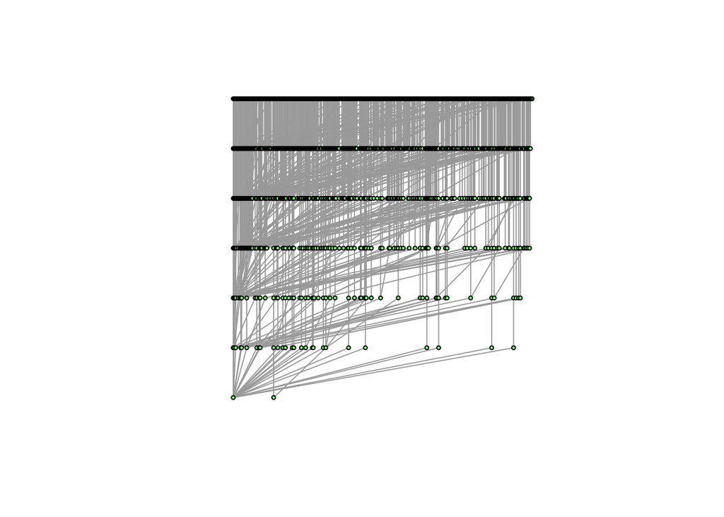

```r
plot(
    igraph_phylogeny,
    layout=layout_as_tree,
    vertex.label=NA,
    vertex.size=v_phylogeny$size/10, # the size were setup for visNetwork
    edge.length = 1,
    edge.arrow.mode = '-'
)
```

By using the `decompose` function of `igraph`, one can separate each component of a graph. Here below are plotted the large bacterial tree and the much smaller archeal one.

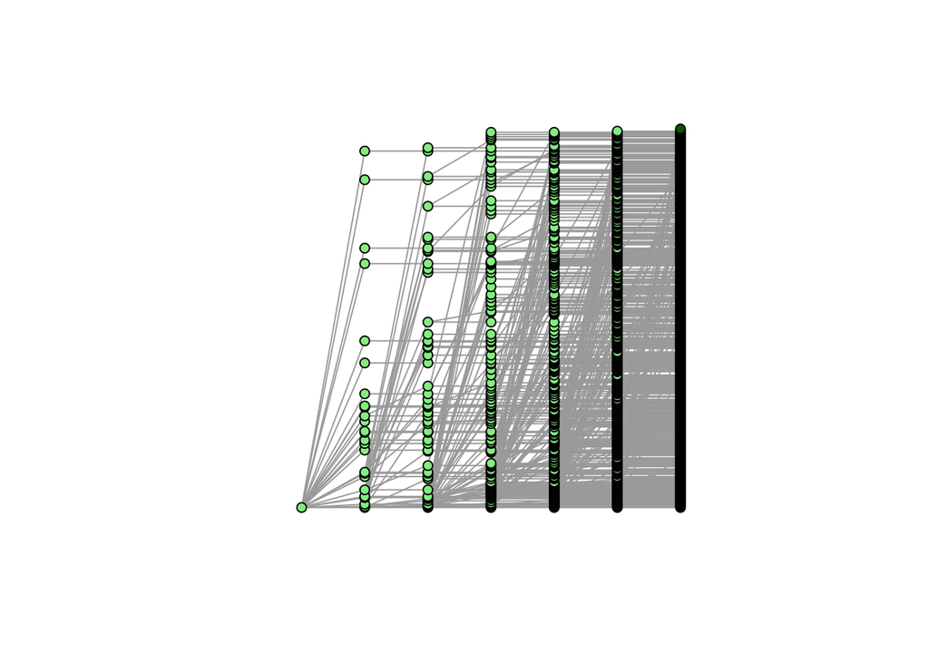

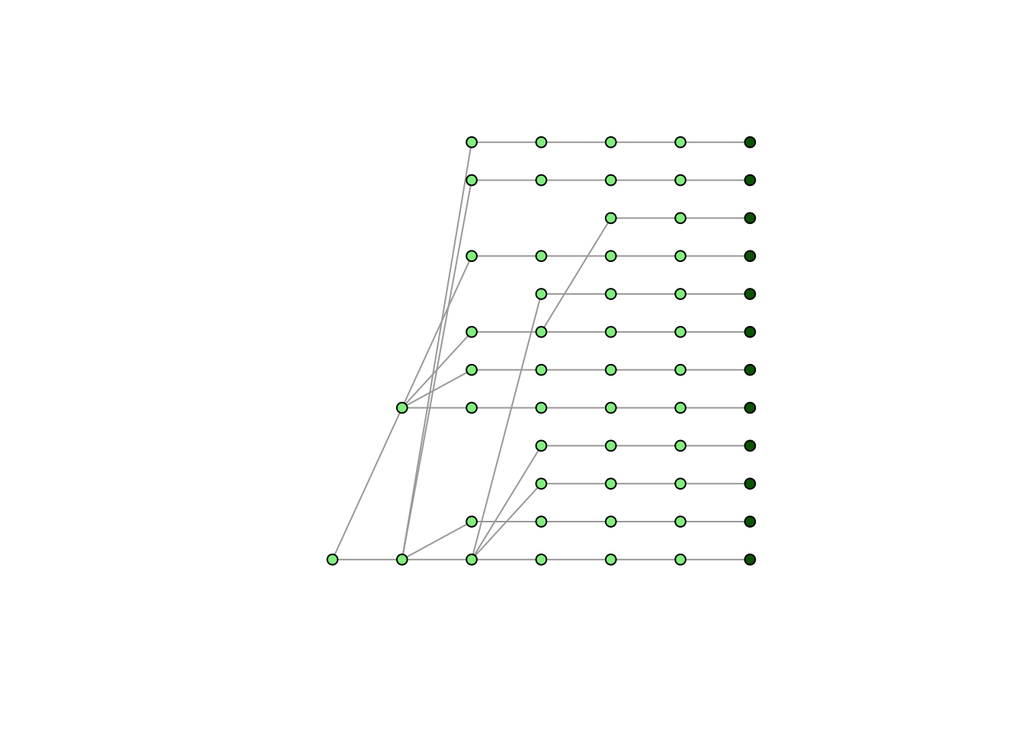

```r
components <- decompose( igraph_phylogeny )
lapply(
    components,
    function( g ){
        lay = layout_as_tree( g )
        # plot(m, layout=-lay[, 2:1]) or maybe this is more what you want: lay[, 2] = -lay[,2] ; plot(m, layout=lay[,2:1])
        plot(
            g,
            layout          = lay[, 2:1],
            vertex.label    = NA,
            vertex.size     = v_phylogeny$size/5, # the size were setup for visNetwork
            edge.length     = 1,
            edge.arrow.mode = '-' # no arrow head
        )
    }
)
```

The Phylogeny can also be visualized using `visNetwork`. The simulation takes a while to stabilize, hence for the `stabilization = FALSE` that prevent locking the display. The labels become visible after zooming enough.

```r
visNetwork(
        edges = e_phylogeny,
        nodes = v_phylogeny
    ) %>%
    visPhysics( stabilization = FALSE ) %>%
    visEdges( smooth = FALSE)
```

[interactive chart not shown]

## “Temperatures”

The idea is to calculate the correlations between sampling depth and “species” distribution. These correlation values will be used as fixed temperature, defined between -a and 1 for the diffusion algorithm.

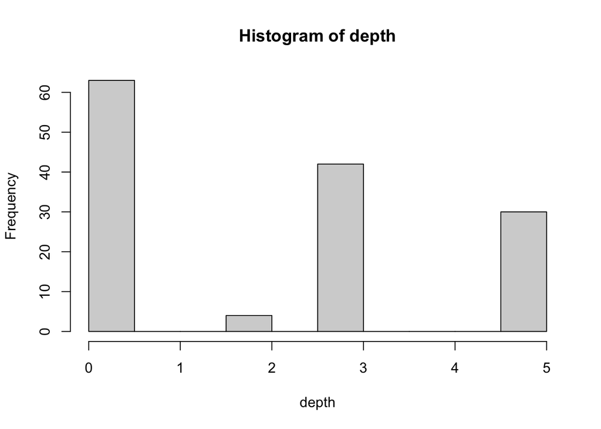

```r
depth_code      <- setNames( c( 0, 2, 3, 5 ), c( 'SRF', 'MIX', 'DCM', 'MES' ))
depth           <- setNames(
    unlist( depth_code[ TARAoceans_metadata$depth ] ),
    unlist( TARAoceans_metadata$sample )
)
hist( depth  )
```

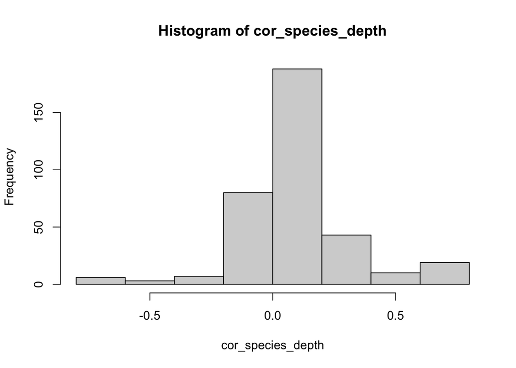

```r
species_score <- log10( 1 + as.matrix( TARAoceans_specfreq[ , -1 ] ))
rownames( species_score ) <- unlist( TARAoceans_specfreq[ , 1 ] )
cor_species_depth <- setNames(
    as.vector( t( cor( depth, species_score ))),
    colnames( species_score )
)
hist( cor_species_depth  )
```

## Diffusion statistics

The `diffuStats` package expects the graph as an `igraph` object, that we have already have produced. It must be converted on-the-fly into an undircected graph. The method `regularisedLaplacianKernel` return a (possibly huge) matrix that might takes some times to compute, although it is not the case here with our “small” graph of about 1,000 vertices. The function `diffuse` with method `z`is extremely fast (`mc` would be much slower).

```r
ker_phylogeny <- regularisedLaplacianKernel(
    graph = as.undirected( igraph_phylogeny ),
    add_diag = 1
);
diffuse_phylogeny <- diffuse(
    K      = ker_phylogeny,
    scores = cor_species_depth,
    method = "z"
)
```

Print the twenty most enriched nodes based on the absolute value of the Z-score. Note that most of them are upper taxa, not “species” and they include a few placeholder taxa. ;-)

```r
tibble(
    id = names( diffuse_phylogeny ),
    z_score = diffuse_phylogeny
) %>%
    arrange( desc( abs( z_score ))) %>%
    slice_head( n = 20 ) %>%
    kable() %>%
    kable_minimal( full_width = F )
```

| id | z_score |
| --- | --- |
| SAR11 clade_order | -5.022086 |
| SAR406 clade(Marine group A)_family | 4.528399 |
| Deferribacterales_order | 4.526148 |
| Nitrospinaceae_family | 4.513036 |
| Deferribacteres_class | 4.510217 |
| Deferribacteres_phylum | 4.372659 |
| family_of_EU802926.1.1368 | -4.194378 |
| Nitrospina_genus | 4.108841 |
| Archaea_domain | 4.106533 |
| Chesapeake-Delaware Bay_family | -3.853019 |
| genus_of_EU800201.1.1303 | -3.766122 |
| Surface 1_family | -3.761349 |
| genus_of_EU802926.1.1368 | -3.747952 |
| family_of_JX945345.1.1443 | -3.721350 |
| genus_of_EF574663.1.1445 | -3.702239 |
| EF574663.1.1445 | -3.699120 |
| SAR116 clade_family | -3.692733 |
| EU802926.1.1368 | -3.684021 |
| EU800201.1.1303 | -3.610615 |
| Chloroplast_class | -3.517676 |

Show the full graph colored by Z-score. The vertex with a border are those given a fixed temperature. It takes a while for the graph to stabilize. Thereafter one can identify blue and clades that correspond to taxonomic groups which abundances are correlated with depth positively (blue) or neagtively, respectively (red).

```r
# A helper function to map -csoe to color
ramp_for_z <- colorRamp( c("red", "white", "blue") )
col_for_z <- function( z_score, thresh = 2.5 ){
    return(
        ifelse(
            is.na( z_score ),
            "white",
            rgb(
                ramp_for_z(
                    pmin( pmax(( z_score + 3 * thresh )/( 6 * thresh ), 0 ), 1 )
                )
            , maxColorValue = 255 )
        )
    )
}
w_phylogeny = v_phylogeny # local copy
w_phylogeny$color       <- col_for_z( diffuse_phylogeny )
w_phylogeny$borderWidth <- ifelse( v_phylogeny$id %in% names( cor_species_depth ), 2, 0 )
visNetwork(
        edges = e_phylogeny,
        nodes = w_phylogeny
    ) %>%
    visPhysics( stabilization = FALSE ) %>%
    visEdges(smooth = FALSE)
```

[interactive chart not shown]